# Band.it Initial Analysis

Tyler Richards

The goal of this analysis is to gather a preliminary understanding of the average band.it consumer, and set up scripts to automatically provide this level of analysis in the future.

Although this data is limited, we have can subset the analysis into three major sections: exploratory, geography, and demographic.

The following is a presentation on 3 layers of analysis from the band.it consumer data containing the names, locations, and amount donated. All PII has been removed from this for privacy.

## Temporal and Exploratory Analysis

The most common effort for a dataset like the one we have is through histograms and time-series plots. Let’s look at the distribution of the donations in buckets, as well as donations over time.

First let’s look at the donations coming in over time.

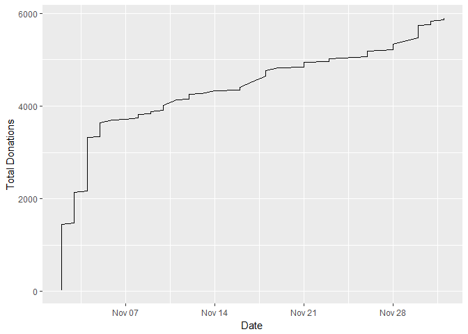

```r
ggplot(consumer_data, aes(x = Date.Pledged, y = cumulative.Donation)) + geom_line() + xlab("Date")+ ylab("Total Donations")
```

It’s seems to be fairly steady over time, with a few large jumps. Let’s check out the distribution of donations.

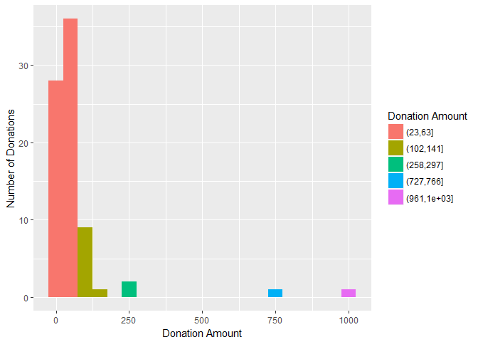

```r
ggplot(consumer_data) + geom_histogram(aes(x = as.numeric(Pledge.Amount), fill = cut(as.numeric(Pledge.Amount), 25)), binwidth = 50) + guides(fill=guide_legend(title="Donation Amount")) + xlab("Donation Amount") + ylab("Number of Donations")
```

The larger donations are clearly the reason for the jump. Let’s dive into some more interesting analytics.

## Location Based Analysis

Using the shipping information given by the customer, we can look at the geographic distribution of the customers using a Google maps API. Here is the result.

[figure not shown]

```r
ggmap(map)+geom_point(aes(x=longitude, y=latitude, size=(count)), data=FM, alpha=.5)
```

## Demographic Analysis

For this analysis, we’ll start with race. Using the last names of individuals and a clever algorithm out of ‘Improving Ecological Inference by Predicting Individual Ethnicity from Voter Registration Records’ by Imai, we can get a probabalistic estimation for the race of individuals with limited data.

Here is the result.

```
## [1] "Proceeding with surname-only predictions..."
```

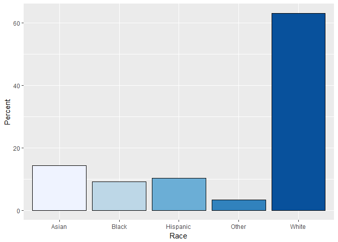

```r
ggplot(data=sumdata, aes(x=key, y=value, fill = key)) +
  geom_bar(colour="black", stat="identity") + ylab("Percent") + xlab("Race") + scale_fill_brewer() + theme_gray() + theme(legend.position = "none")
```

The most common race is white, with the second most common being Asian. Furthermore, using the consumer’s first name we can estimate their gender as well.

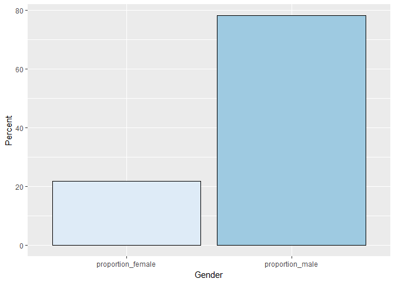

```r
ggplot(data=sumdata, aes(x=key, y=value, fill = key)) +
  geom_bar(colour="black", stat="identity") + ylab("Percent") + xlab("Gender") + scale_fill_brewer() + theme_gray() + theme(legend.position = "none")
```

It’s clear that the overwhelming majority of the individuals who purchase the product are men. Given the high number of casual photographers who are women, this is potentially an outreach area.

Overall, the average customer is a white male who donates/pays under $100 for the product. As more data comes in, we should be able to perform more interesting statistical analysis.